# Time Series: A First Course with Bootstrap Starter

# Lesson 10-1: MA Identification

- We can test for truncation of the sample ACVF to identify the order of an MA model.

## Paradigm 10.1.2. Sequential Testing for the MA Order

- To identify an MA model, we must use the sample ACF rather than the true ACF.
- Take as null hypothesis that the process is an MA(q), such that
  $$H_0 : \gamma (k) = 0 \quad \mbox{for all} \; k > q.$$
- We can use the estimate $\widehat{\rho} (k)$ as test statistic, for any $k > q$.
- Under $H_0$, the asymptotic variance (using Bartlett’s Formula, Remark 9.6.10) is $n^{-1}$ times
  $$\frac{ { \langle f^2 \rangle }_0 }{ { \langle f \rangle }_0^2 } =
  \sum_{|h| \leq q} { \rho (h) }^2.$$
- Plugging in sample estimates, we obtain the test statistic
  $$\sqrt{n} \, \frac{ \widehat{\rho} (k) }{ \sqrt{ \sum_{|h| \leq q } {
  \widehat{\rho} (h) }^2 } }$$
  for each $k > q$.
- How to use this: choose a $q$ to test, and compute the test statistics for various $k > q$. If they fail to reject, keep that value of $q$; otherwise, increment $q$ and repeat the procedure.
- However, this procedure does not account for multiple testing!

## Paradigm 10.1.4. Joint Testing for the MA Order

- We want to test at multiple lags.
- $H_0$ is equivalent to $0 = \mbox{max} \{ | \rho (k) |, k > q \}$.

### **Empirical Rule**

- Let $\widehat{q}$ be the smallest positive integer such that
  $$|\widehat{\rho} (\widehat{q}+k) | < c \sqrt{n^{-1} \log n}$$
  for all $k = 1, \ldots, K_n$, where $c > 0$ is a fixed constant, and $K_n$ is a positive, non-decreasing integer-valued function of $n$ such that $K_n = o(\log n)$.
- $\widehat{q}$ is consistent for $q$.
- Choose $c = 1.96$ and $K_n = 1 + [3 \sqrt{ \log n}]$

## Example 10.1.5. Joint Testing Identification of Non-Defense Capitalization

- We now apply the Empirical Rule to the Non-defense capitalization data.
- We take first differences because of non-stationarity.
- The first $20$ sample autocorrelations and partial autocorrelations are plotted.

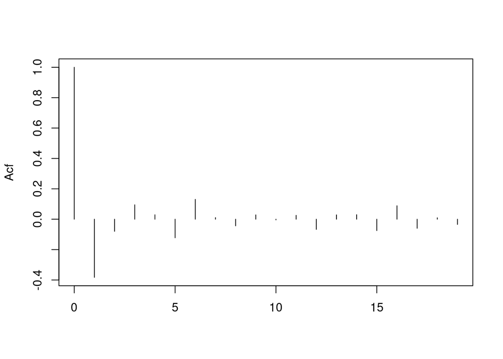

```r
ndc <- read.table("Nondefcap.dat")
ndc <- ts(ndc[,2],start=c(1992,3),frequency=12,names= "NewOrders")
ndc.diff <- diff(ndc)
n <- length(ndc.diff)
gamma.hat <- acf(ndc.diff,lag=n-1,type="covariance",plot=FALSE)$acf[,,1]
kappa.hat <- pacf(ndc.diff,lag=n-1,plot=FALSE)$acf[,,1]
plot(ts(gamma.hat[1:20]/gamma.hat[1],start=0),xlab="",ylab="Acf",type="h")
```

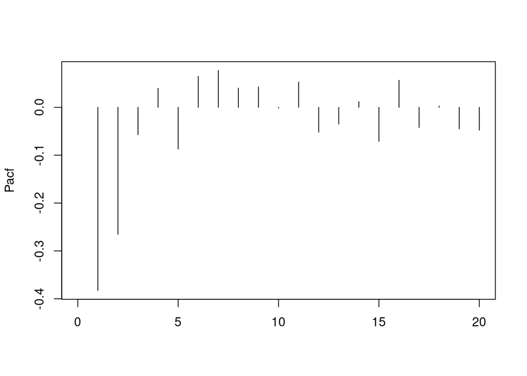

```r
plot(ts(c(NA,kappa.hat[1:20]),start=0),xlab="",ylab="Pacf",type="h")
```

- From visual inspection, we might guess that $q=1$.
- Then we apply the Empirical Rule, where $n =292$ implies $K_n = 5$.
- We print $K_n$ values of the sample autocorrelations.

```r
alpha <- .05
crit <- qnorm(1-alpha/2)
K.n <- 1 + floor(3*sqrt(log(n,base=10)))
rho.hat <- gamma.hat[-1]/gamma.hat[1]
print(rho.hat[1:K.n])
```

```
## [1] -0.38271473 -0.07977748  0.09482173  0.02917913 -0.12226110
```

```r
rho.test <- rho.hat/sqrt(log(n,base=10)/n)
k <- 1
while(k < (n-K.n))
{
    if(max(abs(rho.test[k:(k+K.n-1)])) < crit)
    {
        q.hat <- k-1
        k <- n-K.n
    } else { k <- k+1 }
}
```

- The selected model order is 1, which agrees with the ACF and PACF plots.